# Teste Não Paramétrico

# Introdução

## O que é um teste não paramétrico?

- Para um estatístico é um teste utilizado quando não se conhece a distribuição da variável dependente.
- Para um não estatístico é um teste utilizado quando a distribuição não é normal

## Os testes não paramétricos devem ser **abandonados!**

Motivos:

1 – Os testes não paramétricos são baseados em Ranks e não em medidas reais, ou seja, distorcem a natureza da variável.

2 – São testes com pouco poder explicativo. São mais limitados aos testes paramétricos. Identificam a diferença, mas não o grau de diferença (tamanho de efeito).

3 - Não se pode calcular o intervalo de confiança.

## Usos:

1 – Quando não se conhece a distribuição da variável dependente.

2 – Quando a minha variável é uma categórica ordinal (níveis em ordem).

3 – Quanto o número de amostras é menor que o cálculo de amostra.

### Perguntas

Qual o número de amostras ideal?

Que tipo de cálculo eu devo fazer para chegar ao número de amostra?

**Tudo isso tem ligação (ou deveria ter) com a minha pergunta de pesquisa. Por isso a pergunta de pesquisa é a etapa mais importante.**

# Tipos de testes

```r
testes <- data.frame(Parametrico = c("Teste T ind.", "Teste T pareado", "Anova ind.", "Anova pareada"),
                     N.Parametrico = c("Mann-Whitney", "Wilcoxon", "Kuskal-Wallis", "Friedman"),
                     Tipo = c("Independente","Pareado","Independente", "Pareado"),
                     Grupo = c("2","2","+2","+2"))

knitr::kable(testes, format = "pandoc")
```

[output not shown]

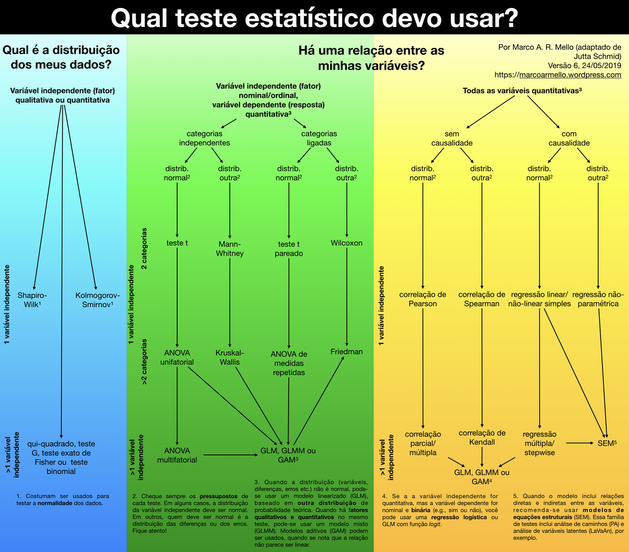

# Exemplo

## Mann-Whitney

Exemplo 1: A adubação com K altera o teor do nutriente no solo? Para isso um solo foi submetido a um experimento com duas doses de K com 4 repetições.

```r
# dados grupo 1
grupo_1 <- c(35,72,54,54)
# dados grupo 2
grupo_2 <- c(56,45,73,54)
#
grupo_1;grupo_2
```

[output not shown]

**Os grupos são estatisticamente diferentes?**

Fórmula de Mann-Whitney:

$$U_{1} =
n_{1}*n_{2}+\frac{n_{1}*(n_{1}+1)}{2}-R_{1}$$
$$U_{2} =
n_{1}*n_{2}+\frac{n_{2}*(n_{2}+1)}{2}-R_{2}$$

# Dentro do R

## Não pareado (Mann-Whitney)

```r
wilcox.test(grupo_1, grupo_2)
```

```
    Wilcoxon rank sum test with continuity correction

data:  grupo_1 and grupo_2
W = 6, p-value = 0.6573
alternative hypothesis: true location shift is not equal to 0
```

### Pareado (Wilcoxon)

```r
wilcox.test(grupo_1, grupo_2, paired = T)

data.frame(grupo_1,grupo_2) |>
  tidyr::pivot_longer(cols = 1:2, values_to = 'valor', names_to = "var") |>
  rstatix::wilcox_test(valor ~ var)
```

[output not shown]

## Kruskal-Wallis

```r
df <- agridat::lehner.soybeanmold

kruskal.test(yield ~ trt, data = df)

df |>
  rstatix::kruskal_test(yield ~ trt)
```

[output not shown]

## Friedman

```r
df <- ToothGrowth  |>
    filter(supp == "VC")  |>
    mutate(bloco = rep(1:10, 3))

friedman.test(len ~ dose | bloco, data = df)

df |> dplyr::group_by(dose,bloco) |> dplyr::count()

df  |>  friedman_test(len ~ dose | bloco)
```

[output not shown]

# Não Paramétrico ou transformar a variável?